# Problema de Alocação

Ícaro Agostino

24 de Abril de 2019 - v2

O problema de **alocação** de pedidos inclui múltiplos centros de produção disponíveis no território brasileiro, assim como múltiplos pontos de pedidos. Dessa forma, a heurística desenvolvida deve alocar cada pedido de forma a minimizar o tempo de resposta, levando em consideração:

- Tempo de setup; (tsp)
- Tempo de fila; (tfl)
- Tempo de produção; (tpr)
- Tempo de viagem; (tvi)

A função objetivo deve então minimizar o tempo total de resposta (ttr):

$$ttr = min \sum_{i,j,a,b}^n setup_i+fila_i+produção_j+viagem_{a,b}$$

Onde: $setup_i$ é o tempo de setup da máquina *i* selecionada; $fila_i$ é o tempo de fila da máquina selecionada; $produção_j$ é o tempo de produção da peça *j* no pedido; $viagem_{a,b}$ é o tempo de viagem entre o centro de produção *a* e o centro de pedido *b*.

## 1. Estrutura do algoritmo

- A entrada da função será o *ponto de pedido* e a *peça* a ser reposta
- A saída será um ranking de *locais de alocação ordenados*

A estrutura do algoritmo é apresentada na Figura 1:

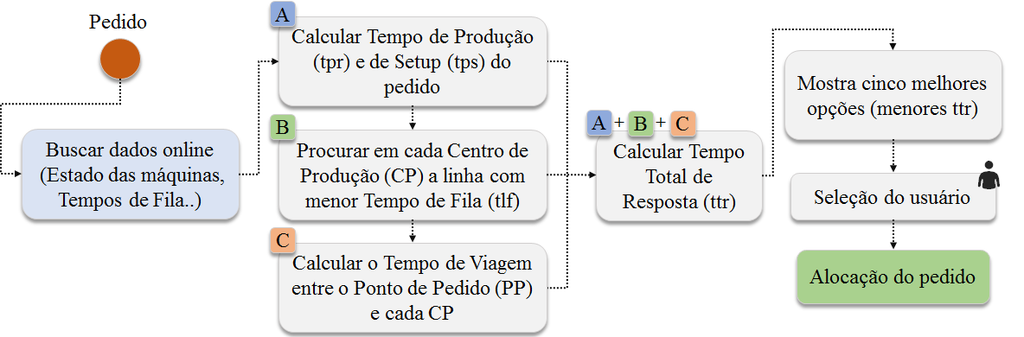

A regra de alocação selecionará um rank de opções ordenadas pelo *ttr* para cada CP, o usuário confirmará a opção e o pedido será alocado na opção selecionada.

Como parâmetros (artificiais) para construção do algoritmo foram considerados:

- 6 Centros de Produçãos (CP)
- 1-2 Máquinas em cada CP (MC)
- 6 Pontos de Pedidos (PP)
- 5 Tipos de Peças (TP)

Os dados fictícios foram hospedados no [GitHub](https://github.com/icaroagostino/BD/tree/master/aloc) no formato **.txt**, os dados serão lidos em tempo real. Todas as variáveis estão em minutos.

```r
# Tempo de setup e produção das peças (min)

head(dplyr::as_tibble(read.table("https://raw.githubusercontent.com/icaroagostino/BD/master/aloc/peca.txt", header = T)),5)
```

```
## # A tibble: 5 x 3
##   peca      tpr   tsp
##   <fct>   <int> <int>
## 1 botao      60    20
## 2 bico       95    20
## 3 grade     125    30
## 4 suporte   115    25
## 5 moldura    85    20
```

```r
# Estado das máquinas (tempo de fila (min))

head(dplyr::as_tibble(read.table("https://raw.githubusercontent.com/icaroagostino/BD/master/aloc/maq4.txt", header = T)),5)
```

```
## # A tibble: 5 x 3
##   cp    maq     tfl
##   <fct> <fct> <int>
## 1 sp    sp1       0
## 2 sp    sp2       0
## 3 go    go1       0
## 4 pa    pa1       0
## 5 mc    mc1       0
```

```r
# Matriz de distância entre os CP e PP (min)

head(dplyr::as_tibble(read.table("https://raw.githubusercontent.com/icaroagostino/BD/master/aloc/tvi2.txt", header = T)),5)
```

```
## # A tibble: 5 x 3
##   pp    cp      tvi
##   <fct> <fct> <int>
## 1 fl    sp      548
## 2 fl    go     1125
## 3 fl    pa      327
## 4 fl    mc     2460
## 5 fl    jp     2760
```

A regra de alocação foi escrita em linguagem R 3.5.2, na forma de função, em que parâmetros de entrada serão Ponto de Pedido e Tipo da Peça e a saída os locais para alocação.

```r
# Função alocar

alocar <- function(ppd, pc){

  # busca na rede os dados em tempo real
  tvi <- dplyr::as_tibble(read.table('https://raw.githubusercontent.com/icaroagostino/BD/master/aloc/tvi2.txt', header = T))
  maq <- read.table("https://raw.githubusercontent.com/icaroagostino/BD/master/aloc/maq4.txt", header = T)
  peca <- dplyr::as_tibble(read.table("https://raw.githubusercontent.com/icaroagostino/BD/master/aloc/peca.txt", header = T))

  # Calcular tempo de producao + setup (A)
  a <- dplyr::filter(peca, peca == pc)

  # Buscar menor tempo de fila em cada cp (B)
  b <- c()
  for (i in unique(maq$cp)){b <- rbind(b, dplyr::arrange(dplyr::filter(maq, cp == i),tfl)[1,])}

  # calcular tempo de viagem entro o pp e os cp (C)
  c <- dplyr::filter(tvi, pp == ppd)

  # Calcular tempo total de resposta (A + B + C)
  tt <- dplyr::tibble(PP = ppd,CP = unique(maq$cp),
                      MC = b[,2],
                      TFL = b[,3],
                      TVI = dplyr::pull(c[,3]),
                      TPR = dplyr::pull(a[,2]+a[,3]),
                      TT = dplyr::pull(b[,3] + c[,3]) + dplyr::pull(a[,2]+a[,3]))

  return(head(tt <- dplyr::arrange(tt, TT), 5)) # Retorna os 5 menores tempos
}
```

## 2. Teste: Alocação dinâmica de pedidos

Com o objetivo de testar a capacidade da regra de alocação, foi realizado um experimento simples, em que foram geradas 50 ordens de pedidos, considerando dados artificiais (disponíveis no GitHub):

- Ordens de Serviço (OS) - [Link](https://github.com/icaroagostino/BD/blob/master/aloc/OS.txt)
- Tempos de Setup e produção - [Link](https://github.com/icaroagostino/BD/blob/master/aloc/peca.txt)
- Tempos de viagem entre CP e PP - [Link](https://github.com/icaroagostino/BD/blob/master/aloc/tvi2.txt)
- Status de filas das máquinas - [Link](https://github.com/icaroagostino/BD/blob/master/aloc/maq4.txt)

Todas as máquinas iniciaram com o tempo de fila = 0 e de forma dinâmica os pedidos foram sendo alocados conforme a ocorrência das OS. Os pedidos foram gerados de forma aleatória, sendo o intervalo entre pedidos definido aleatoriamente entre 0 e 30 minutos para estressar modelo a realizar as alocações.

```r
# Leitura dos dados
tvi <- dplyr::as_tibble(read.table('tvi2.txt', header = T))
maq <- read.table("maq4.txt", header = T)
peca <- dplyr::as_tibble(read.table("peca.txt", header = T))
os <- dplyr::as_tibble(read.table("OS.txt", header = T))
```

O experimento teste foi então realizado em uma estrutura de loop em que cada ordem era lida na sequência 1:50:

```r
library(dbplyr)
maq0 <- maq

for (n in 1:50){

  if (n-1 != 0){maq[which(maq$tfl > 0),3] <- maq[which(maq$tfl > 0),3] - (os[[n,4]] - os[[n-1,4]])}

  maq[which(maq$tfl < 0),3] <- 0

cat('\n\n',paste0('Buscando OS de número ',n,': peça tipo ',as.character(os[[n,3]]),' para PP ',as.character(os[[n,2]]),'\n\n'))

z <- alocar(as.character(os[[n,2]]), as.character(os[[n,3]])) %>% print

maq[which(maq == as.character(z[[1,3]]),
          arr.ind = T)[,1],3] <-
  maq[which(maq == as.character(z[[1,3]]), arr.ind = T)[,1],3] + z[[1,6]]

maq0 <- cbind(maq0, nc = maq$tfl)
colnames(maq0)[colnames(maq0) == 'nc'] <- paste("SO", n, sep = "")

}
```

Graficamente o tempo de fila (min) de cada CP assim como de cada máquina é mostrado a seguir, foi considerado o tempo acumulado no momento após a realização de cada pedido.

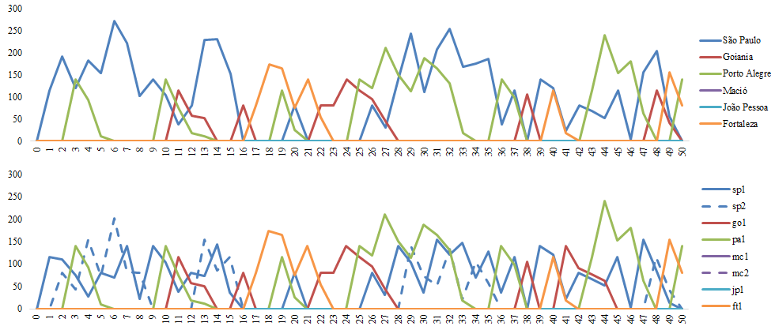

Os resultados do teste proposto apenas avaliam o funcionamento do algoritmo de alocação, não qualificando os locais de produção, assim como a quantidade de máquinas em cada localidade.

## 3. Simplificações e limitações

- O tempo total considera que a saída para entrega após produção é imediata, no futuro o intervalo entre o fim da produção e o início do transporte deve ser considerado.
- É considerado que o tempo de setup é sempre igual para o mesmo tipo de peça, e que o tempo de produção é determinístico, com inclusão de dados reais será possível incorporar efeitos estocásticos nessas variáveis.